### R commands used in the App

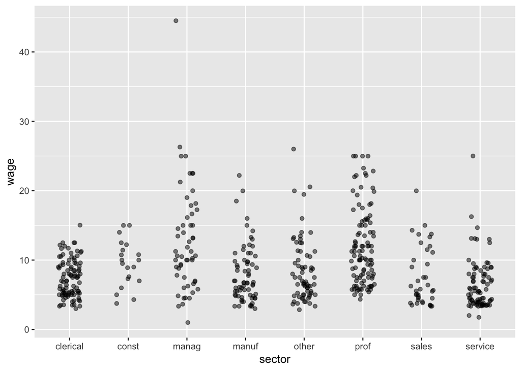

```r
gf_jitter(wage ~ sector,
          data = mosaicData::CPS85,
          width = 0.2, alpha = 0.5)
```

The `width = 0.2` argument controls how spread out the points are horizontally in each of the groups defined by the explanatory variable. The `alpha = 0.5` argument makes the points semi-transparent so that it’s easy to see when one point is lying on top of another.

## Calculating the statistics

The statistics are calculated using the `df_stats()` function. This function takes the same formula and data arguments as `gf_jitter()`, with additional arguments listing the statistics to be calculated.

```r
df_stats(wage ~ sector,
         data = mosaicData::CPS85,
         mean, ci.mean(level = 0.95), sd)
```

```
##     sector mean_wage     lower     upper  sd_wage
## 1 clerical  7.422577  6.878605  7.966550 2.699018
## 2    const  9.502000  7.937018 11.066982 3.343877
## 3    manag 12.704000 10.656863 14.751137 7.572513
## 4    manuf  8.036029  7.039356  9.032703 4.117607
## 5    other  8.500588  7.386897  9.614279 4.601049
## 6     prof 11.947429 10.878431 13.016426 5.523833
## 7    sales  7.592632  6.201519  8.983745 4.232272
## 8  service  6.537470  5.735387  7.339552 3.673278
```

## Graphing the statistics

Once the statistics have been calculated, they are plotted using the `gf_errorbar()` function, like this:

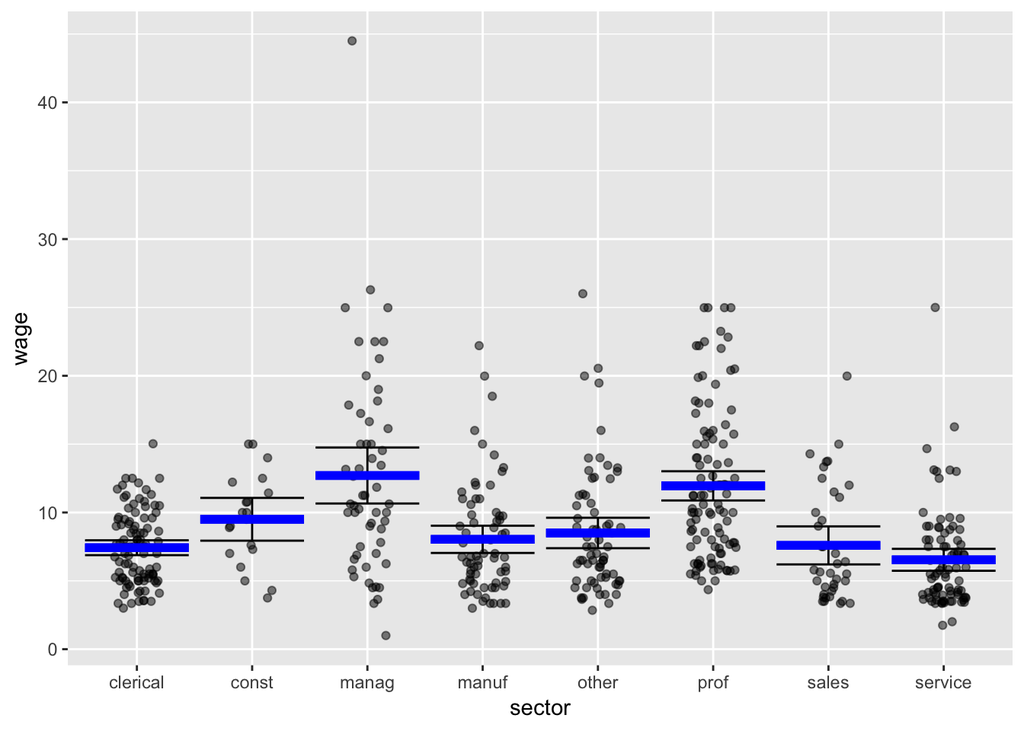

```r
Stats <- df_stats(wage ~ sector,
                  data = mosaicData::CPS85,
                  mean, ci.mean(level = 0.95), sd)
gf_jitter(wage ~ sector,
          data = mosaicData::CPS85,
          width = 0.2, alpha = 0.5) %>%
  gf_errorbar(lower + upper ~ sector,
              data = Stats, color = "black") %>%
  gf_errorbar(mean_wage + mean_wage ~ sector,
              data = Stats,
              color = "blue", size = 2)
```

### Drawing a sample

The app includes data frames with thousands of rows. From these, a random sample of size n is drawn for the display and calculation of statistics. For non-stratified sampling, the command to do this is

```r
The_sample <- mosaicData::CPS85 %>%
  sample_n(size = 10)
```

For stratified sampling, the command is a little different and results in n rows being drawn from each of the groups defined by the categorical explanatory variable (`sector` in this example).

```r
The_stratified_sample <- mosaicData::CPS85 %>%
  group_by(sector) %>%
  sample_n(size = 10)
```

### Refinements

When there is no explanatory variable, the plotting tilde-formula should have a 1 on the right side of the tilde, e.g. `wage ~ 1`. On its own, this doesn’t make a satisfactory graphic since the points are scattered across the full width of the graph. To avoid this, the scale of the x-axis is set explicitly and the labeling of the x-axis is turned off. This involves a rather long pair of commands, the first of which defines a graphical “theme” and the second makes the plot, sets the axis limits, and uses the theme.

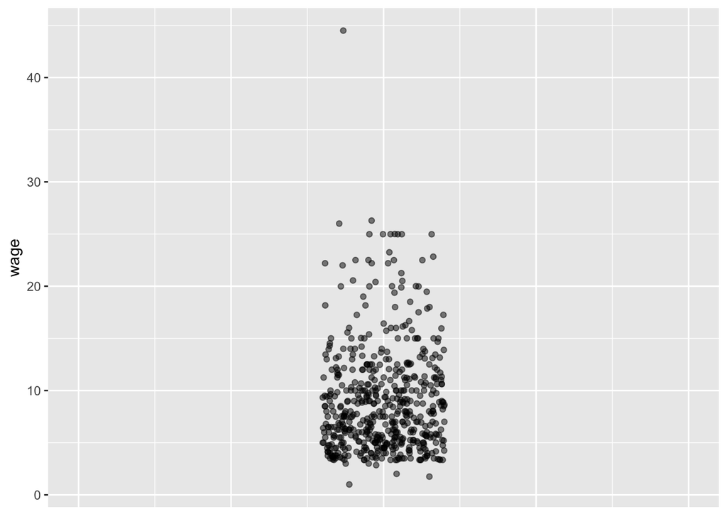

```r
no_x_axis <- theme(axis.title.x=element_blank(),
      axis.text.x=element_blank(),
      axis.ticks.x=element_blank())
gf_jitter(wage ~ 1,
          data = mosaicData::CPS85,
          width = 0.2, alpha = 0.5) %>%
  gf_lims(x = c(0,2)) %>%
  gf_theme(no_x_axis)
```